# Bayesian inference on the two-piece normal distribution using rstan

[F. Javier Rubio](https://sites.google.com/site/fjavierrubio67)

May 01, 2020

# The two-piece normal distribution

The two-piece normal, binormal, split normal, or asymmetric normal (Wallis 2014), is obtained by continuously joining two half-normal densities with different scale parameters but with the same location parameter:
$$s(x \mid \mu, \sigma_1, \sigma_2) = \dfrac{2}{\sigma_1 + \sigma_2} \left[\phi\left(\dfrac{x-\mu}{\sigma_1}\right)I(x<\mu) + \phi\left(\dfrac{x-\mu}{\sigma_2}\right)I(x\geq\mu)\right],$$
where $\phi(x) = \dfrac{1}{\sqrt{2\pi}}\exp\left(-\dfrac{x^2}{2}\right)$. This distribution has a peculiar history as it has been re-invented several times, under different levels of generality, and different parameterisations (Rubio and Steel 2020; Wallis 2014). The two-piece normal density is unimodal by construction, it is continuous, and differentiable everywhere. However, it is not twice differentiable at the mode. Simulating from the two-piece normal distribution is easy using the `twopiece` [R package](https://rpubs.com/FJRubio/twopiece), as illustrated in our first example. The two-piece normal is a member of the larger family of two-piece distributions (Rubio and Steel 2020).

The two-piece normal distribution has been applied in many areas such as finance, medicine, economy, psychology, and etcetera (Rubio and Steel 2020). See [The Two Piece Normal Distribution](https://quantgirl.blog/two-piece-normal/) and [Fan Charts](https://quantgirl.blog/fan-charts/) for applications in finance.

# Bayesian inference using rstan

Rubio and Steel (2014) studied different types of priors for two-piece distributions. For illustrative purposes, we will adopt the following priors for the parameters $(\mu,\sigma_1,\sigma_2)$:

$$\begin{align}
\mu &\sim N(0,100),\\
\sigma_1 &\sim InvGamma(0.01,0.01),\\
\sigma_2 &\sim InvGamma(0.01,0.01).
\end{align}$$

Next, we present two illustrative examples. Example 1 describes how to simulate from the two-piece normal distribution using the `twopiece` R package, how to sample from the posterior distribution of $(\mu,\sigma_1,\sigma_2)$ using `rstan`, and how to calculate the posterior predictive distribution. Example 2 presents a real data application. The `rstan` code used in both examples can be found at the end of this document.

# Example 1: Simulated data

```r
rm(list=ls())
#------------------------------------------------
# Data simulation
#------------------------------------------------
# install.packages("devtools")
#devtools::install_github("medewitt/twopiece")
library(twopiece)

N <- 1000 # Sample size
set.seed(123) # Seed
# Simulated sample from a twopiece normal using the twopiece parameterisation
y <- rtp3(N,10,3,1,FUN=rnorm,param="tp")

# Data list
datasim <- list(y = y, N = N)

#------------------------------------------------
# Posterior simulation
#------------------------------------------------
library(rstan)

fit1 <- stan(
  file = "TPN.stan",  # Stan program
  data = datasim,    # named list of data
  chains = 1,             # number of Markov chains
  warmup = 1000,          # number of warmup iterations per chain
  iter = 11000,            # total number of iterations per chain
  cores = 2,              # number of cores (could use one per chain)
  refresh = 0             # no progress shown
)

# Trace plots and histograms (thinned samples)
index = seq(1,10000, by = 5) # thinning index
# thinned samples
mup <- extract(fit1, "mu")$mu[index]
sigma1p <- extract(fit1, "sigma1")$sigma1[index]
sigma2p <- extract(fit1, "sigma2")$sigma2[index]

# summaries
summary(mup)
```

```
##    Min. 1st Qu.  Median    Mean 3rd Qu.    Max.
##   9.553   9.975  10.069  10.066  10.159  10.458
```

```r
summary(sigma1p)
```

```
##    Min. 1st Qu.  Median    Mean 3rd Qu.    Max.
##   2.653   2.994   3.062   3.063   3.129   3.424
```

```r
summary(sigma2p)
```

```
##    Min. 1st Qu.  Median    Mean 3rd Qu.    Max.
##  0.6875  0.8705  0.9233  0.9268  0.9804  1.2051
```

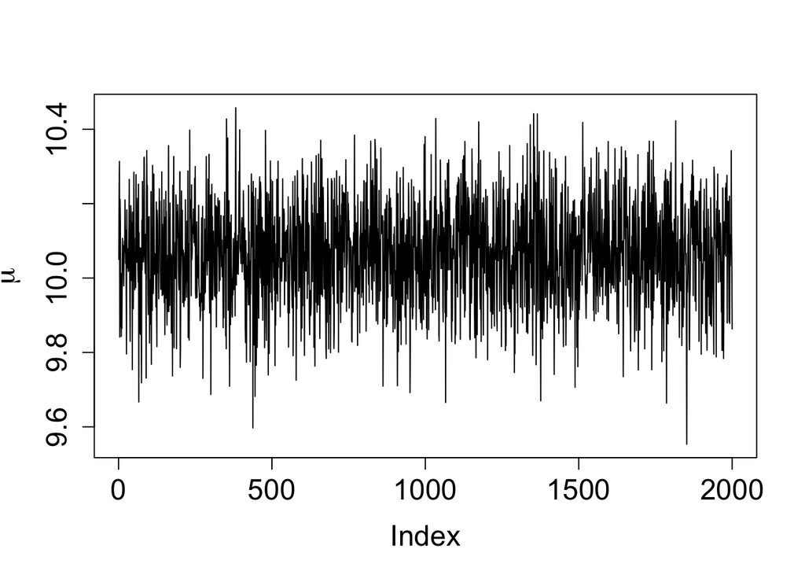

```r
# traceplots
plot(mup, type="l", ylab = expression(mu), cex.axis = 1.5, cex.lab = 1.5)
```

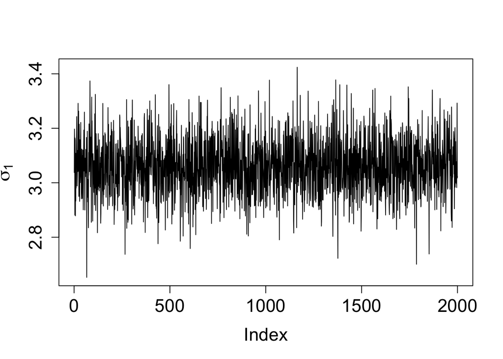

```r
plot(sigma1p,type="l", ylab = expression(sigma[1]), cex.axis = 1.5, cex.lab = 1.5)
```

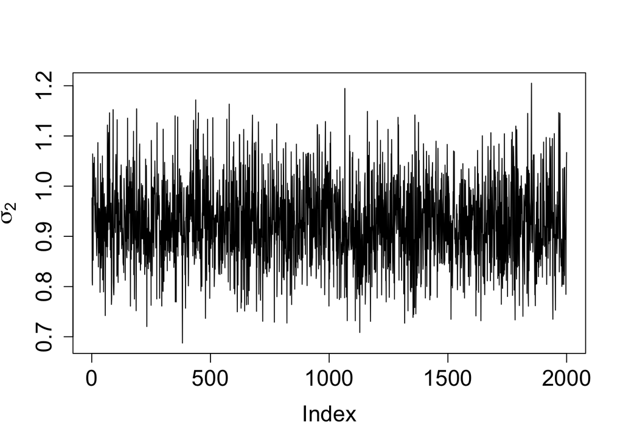

```r
plot(sigma2p,type="l", ylab = expression(sigma[2]), cex.axis = 1.5, cex.lab = 1.5)
```

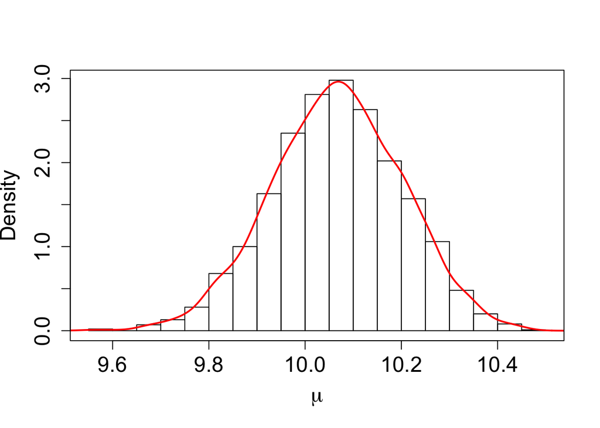

```r
# histograms
hist(mup, breaks = 30, probability = T,
     main = "", xlab = expression(mu), cex.axis = 1.5, cex.lab = 1.5)
points(density(mup), type="l", col="red", lwd = 2)
box()
```

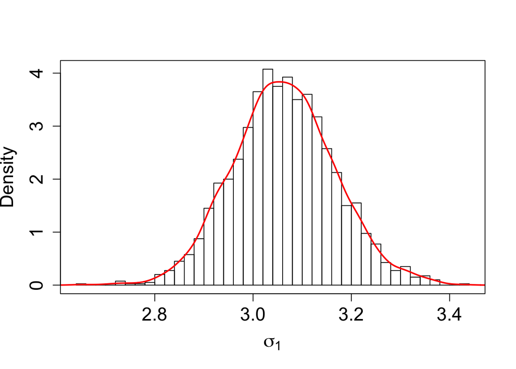

```r
hist(sigma1p, breaks = 30, probability = T,
     main = "", xlab = expression(sigma[1]), cex.axis = 1.5, cex.lab = 1.5)
points(density(sigma1p), type="l", col="red", lwd = 2)
box()
```

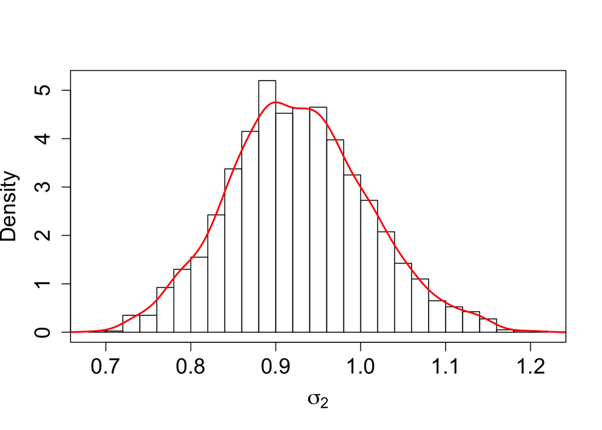

```r
hist(sigma2p, breaks = 30, probability = T,
     main = "", xlab = expression(sigma[2]), cex.axis = 1.5, cex.lab = 1.5)
points(density(sigma2p), type="l", col="red", lwd = 2)
box()
```

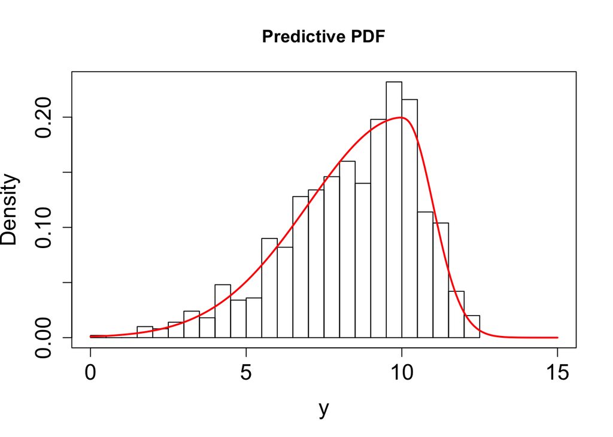

```r
#------------------------------------------------
# Posterior predictive density function
#------------------------------------------------
dpred <- Vectorize(function(x){
  val <- vector()
  for(i in 1:length(index)) val[i] <- dtp3(x,mup[i],sigma1p[i],sigma2p[i], FUN=dnorm, param ="tp")
  return(mean(val))
})

hist(y,probability = T, breaks = 20, xlim = c(0,15),
     main="Predictive PDF", xlab = "y", cex.axis = 1.5, cex.lab = 1.5)
curve(dpred, 0, 15, n = 250, add = T, col="red", lwd = 2 )
box()
```

# Example 2: Real Data - Body Mass Index

```r
rm(list=ls())
# Data: BMI of 100 female Australian athletes
y <- c(20.56,20.67,21.86,21.88,18.96,21.04,21.69,20.62,22.64,19.44,25.75,21.20,22.03,25.44,22.63,
       21.86,22.27,21.27,23.47,23.19, 23.17,24.54,22.96,19.76,23.36,22.67,24.24,24.21,20.46,20.81,
       20.17,23.06,24.40,23.97,22.62,19.16,21.15,21.40,21.03,21.77,21.38,21.47,24.45,22.63,22.80,
       23.58,20.06,23.01,24.64,18.26,24.47,23.99,26.24,20.04,25.72,25.64,19.87,23.35,22.42,20.42,
       22.13,25.17,23.72,21.28,20.87,19.00,22.04,20.12,21.35,28.57,26.95,28.13,26.85,25.27,
       31.93,16.75,19.54,20.42,22.76,20.12,22.35,19.16,20.77,19.37,22.37,17.54,19.06,20.30,20.15,
       25.36,22.12,21.25,20.53,17.06,18.29,18.37,18.93,17.79,17.05,20.31)
summary(y)
```

```
##    Min. 1st Qu.  Median    Mean 3rd Qu.    Max.
##   16.75   20.27   21.82   21.99   23.39   31.93
```

```r
N <- length(y)

# Data list
datasim <- list(y = y, N = N)

#------------------------------------------------
# Posterior simulation
#------------------------------------------------
library(rstan)

fit1 <- stan(
  file = "TPN.stan",  # Stan program
  data = datasim,    # named list of data
  chains = 1,             # number of Markov chains
  warmup = 1000,          # number of warmup iterations per chain
  iter = 11000,            # total number of iterations per chain
  cores = 2,              # number of cores (could use one per chain)
  refresh = 0             # no progress shown
)

# Trace plots and histograms (thinned samples)
index = seq(1,10000, by = 5) # thinning index
# thinned samples
mup <- extract(fit1, "mu")$mu[index]
sigma1p <- extract(fit1, "sigma1")$sigma1[index]
sigma2p <- extract(fit1, "sigma2")$sigma2[index]

# summaries
summary(mup)
```

```
##    Min. 1st Qu.  Median    Mean 3rd Qu.    Max.
##   18.45   20.37   20.80   20.76   21.16   22.60
```

```r
summary(sigma1p)
```

```
##    Min. 1st Qu.  Median    Mean 3rd Qu.    Max.
##  0.6642  1.5769  1.8018  1.8172  2.0459  3.1841
```

```r
summary(sigma2p)
```

```
##    Min. 1st Qu.  Median    Mean 3rd Qu.    Max.
##   2.197   3.103   3.371   3.395   3.667   4.969
```

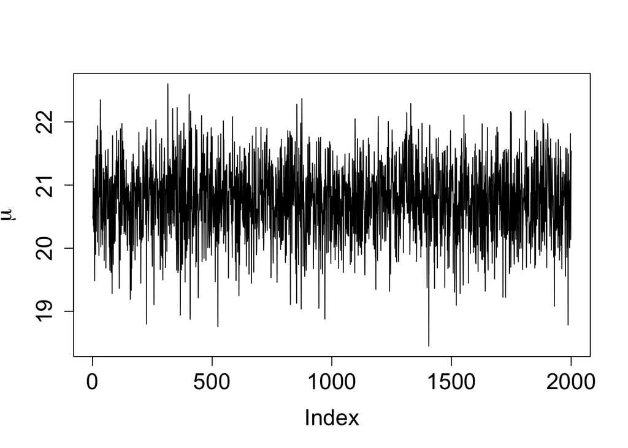

```r
# traceplots
plot(mup, type="l", ylab = expression(mu), cex.axis = 1.5, cex.lab = 1.5)
```

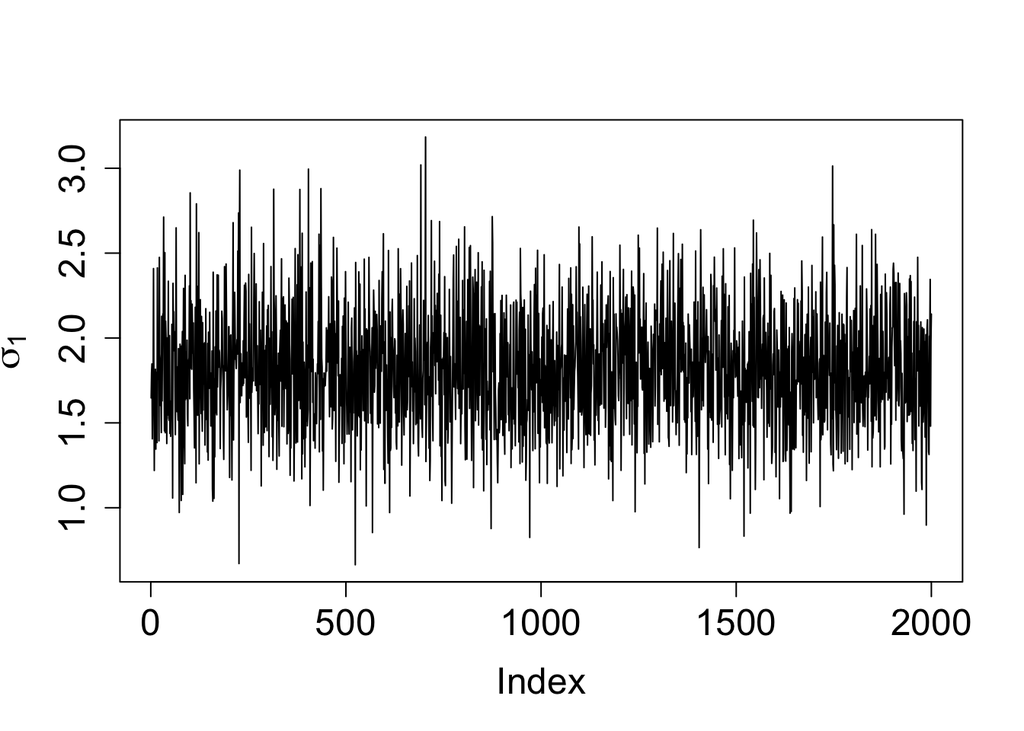

```r
plot(sigma1p,type="l", ylab = expression(sigma[1]), cex.axis = 1.5, cex.lab = 1.5)
```

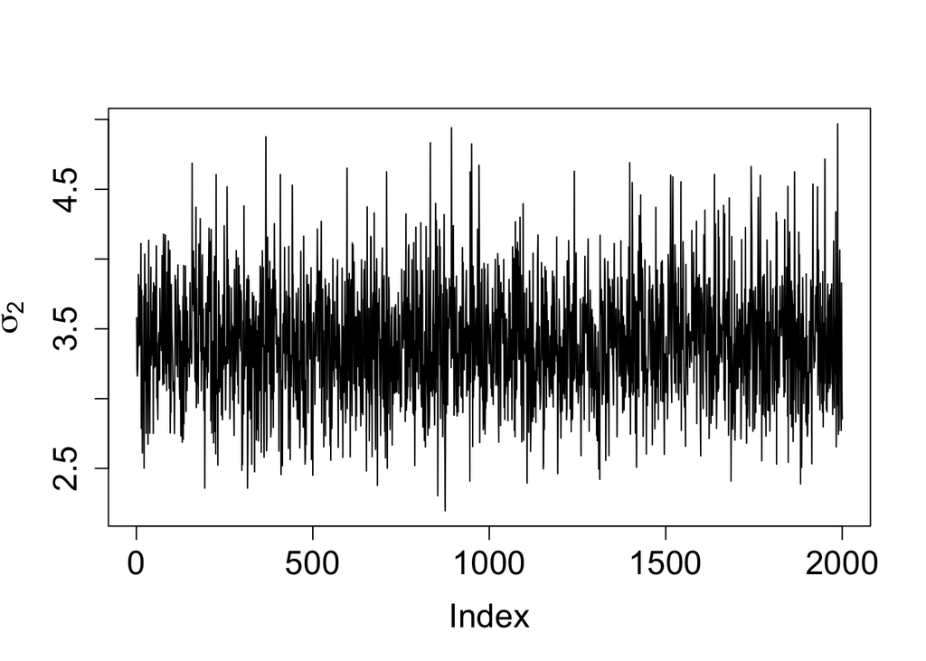

```r
plot(sigma2p,type="l", ylab = expression(sigma[2]), cex.axis = 1.5, cex.lab = 1.5)
```

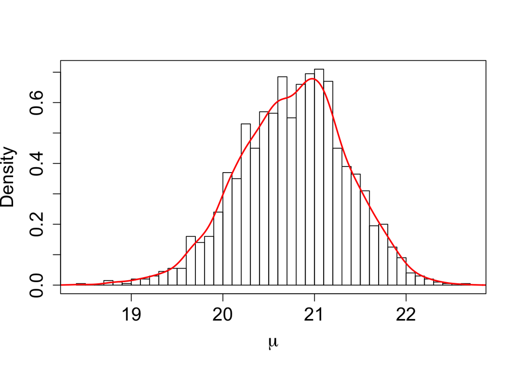

```r
# histograms
hist(mup, breaks = 30, probability = T,
     main = "", xlab = expression(mu), cex.axis = 1.5, cex.lab = 1.5)
points(density(mup), type="l", col="red", lwd = 2)
box()
```

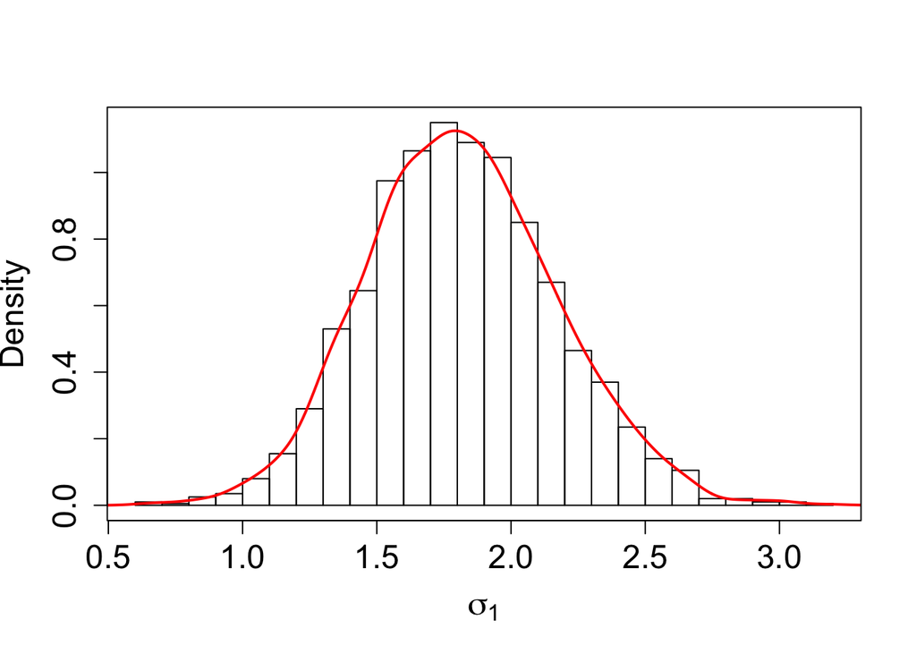

```r
hist(sigma1p, breaks = 30, probability = T,
     main = "", xlab = expression(sigma[1]), cex.axis = 1.5, cex.lab = 1.5)
points(density(sigma1p), type="l", col="red", lwd = 2)
box()
```

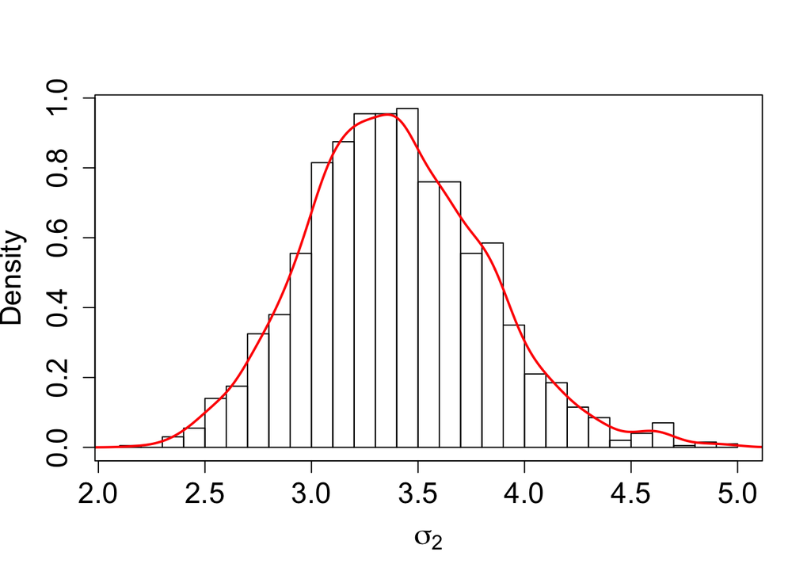

```r
hist(sigma2p, breaks = 30, probability = T,
     main = "", xlab = expression(sigma[2]), cex.axis = 1.5, cex.lab = 1.5)
points(density(sigma2p), type="l", col="red", lwd = 2)
box()
```

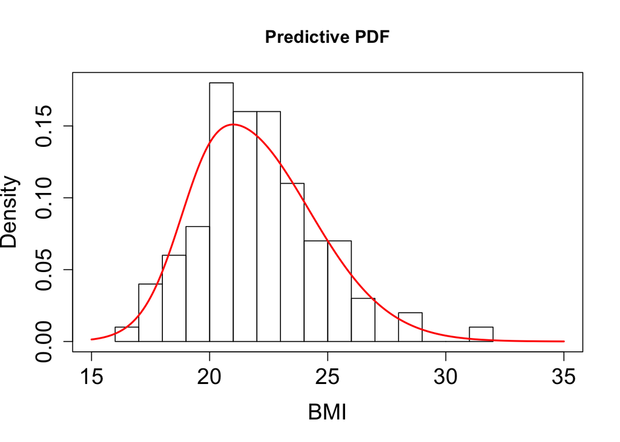

```r
#------------------------------------------------
# Posterior predictive density function
#------------------------------------------------
dpred <- Vectorize(function(x){
  val <- vector()
  for(i in 1:length(index)) val[i] <- dtp3(x,mup[i],sigma1p[i],sigma2p[i], FUN=dnorm, param ="tp")
  return(mean(val))
})

hist(y, probability = T, breaks = 20, xlim = c(15,35),
     main="Predictive PDF", xlab = "BMI", cex.axis = 1.5, cex.lab = 1.5)
curve(dpred, 15, 35, n = 250, add = T, col="red", lwd = 2 )
box()
```

# TPN.stan code

```r
data {
  int < lower = 1 > N; // Sample size
  vector[N] y; // Sample
}

parameters {
  real mu; // mean
  real < lower = 0 > sigma1;
  real < lower = 0 > sigma2;
}

model {
  // Priors
  target += normal_lpdf(mu | 0, 100);
  target += inv_gamma_lpdf(sigma1 | 0.01, 0.01);
  target += inv_gamma_lpdf(sigma2 | 0.01, 0.01);
  // Likelihood
  for(n in 1:N){
    if(y[n] <  mu)
    {
      target += normal_lpdf( (y[n]-mu)/sigma1 | 0 , 1) + log(2) - log(sigma1 + sigma2);
    }
    if(y[n] >=  mu){
      target += normal_lpdf( (y[n]-mu)/sigma2 | 0 , 1) + log(2) - log(sigma1 + sigma2);
    }
  }
}

generated quantities {
}
```

# References

**References**

Rubio, F.J., and M.F.J. Steel. 2014. “Inference in Two-Piece Location-Scale Models with Jeffreys Priors.” *Bayesian Analysis* 9 (1): 1–22.

———. 2020. “The Family of Two-Piece Distributions.” *Significance* 17 (1): 12–13.

Wallis, K.F. 2014. “The Two-Piece Normal, Binormal, or Double Gaussian Distribution: Its Origin and Rediscoveries.” *Statistical Science* 29 (1): 106–12.